[figure not shown]

# Tema 5: Inferencia en RLS

## **Parte 1: Explorando la relación entre RCT y RLS**

### **Parte 1: Explorando la relación entre RCT y RLS**

Nota: Este ejercicio está basado en el ejercicio “Activity 1: Randomized Trials” diseñado por el Prof. Spiro Maroulis (Disponible en: https://spiromar.github.io/teaching/paf573/IC1-randomized-trials.html).

[figure not shown]

3. Presiona los siguientes 3 botones en orden sucesivo: Setup, Treat y export-data. Con ello se habrá ejecutado una vez el modelo, y habremos exportado los datos. Ahora Abre R Studio, y crea un script en blanco. En dicho script crearás el código para analizar los datos de este experimento.

[figure not shown]

4. Cree una carpeta donde guardará los archivos de esta clase. Guarde el script en dicha ubicación, busque el archivo de datos que descargó desde la página del experimento aleatorio (student-data.csv) y guardela en dicha ubicación. Luego, en su script, ponga el titulo “Tema 5”, en forma de comentario, limpie el ambiente, defina el directorio como la carpeta que recién creo, instale si es necesario y cargue los siguientes paquetes: readr, GGally, tidyverse, ggplot2.
5. Importe la base de datos student-data.csv usando el comando read_delim (del paquete readr). Antes de hacerlo, abra la base en bloc de notas para ver cuál es el separador de datos que utiliza el archivo. Asignele a la base de datos el nombre datos.
6. La base de datos tendrá 500 filas de datos, con las siguientes variables currach, initach, seas y treat. Estas variables corresponden al: rendimiendo post tratamiento, rendimiento pre tratamiento, nivel socioeconómico (NSE), y una variable dummy indicando con el valor 1 si el estudiante pertenece al grupo de tratamiento. Cambie los nombres de las variables por los siguientes (respectivamente): posT_rendimiento, preT_rendimiento, NSE, Grupo.
7. Convierte la variable grupo en una variable factor con los niveles: Grupo de Tratamiento (cuando el valor = 1) y Grupo de Control (cuando el valor = 0).
8. En lo que sigue observaremos gráficamente la relacion entre el rendimiento y el NSE de los estudiantes usando la función ggpairs del paquete GGally (Nota: el paquete GGally requiere el paquete ggplot2). Esta función creará una figura que incluye: el histograma de cada variable, el gráfico de dispersión de los casos en base a cada par de variables, y la correlación entre ambas variables. Usa el siguiente comando para seleccionar las tres variables relevantes (NSE y rendimiento previo y posterior al tratamiento) y crear la figura. Note que el operador *pipe (%>%)*, cumple la función de enviar el output (salida) de la función de la izquierda a la función de la derecha: en este caso, la base de datos es enviada como input (entrada) a la función seleccionar, y el output de dicha función es a su vez enviada como input a la función ggpairs. Note además que la función select es parte del paquete tidyverse. ¿Las relaciones observadas tienen sentido considerando los parámetros definidos en la simulación?

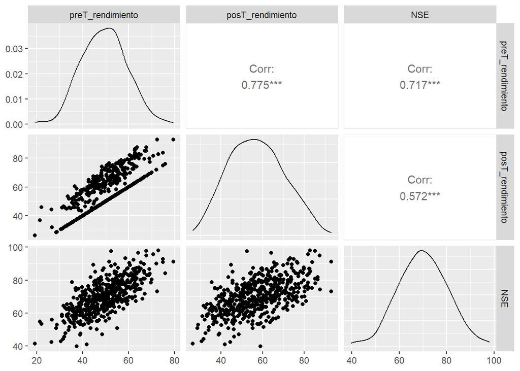

```r
# Realizar gráficos de variables de rendimiento y SES
datos %>% dplyr::select(preT_rendimiento,posT_rendimiento,NSE) %>% ggpairs()
```

9. Compare el rendimiento de los estudiantes antes del tratamiento en el grupo de control y de tratamiento, usando los comandos descritos a continuación. Primero, use el comando ggplot del paquete ggplot2. Este comando funciona con capas, donde, usando el signo más se van agregando sucesivamente nuevas especificaciones al gráfico o figura. Después de *ggplot*, en paréntesis se indica la base de datos (datos), luego en aes se indica x= a la variable a gráficar (pre_rendimiento). Luego, con la opción fill=grupo se indica que los datos deben ser agrupados en base a la variable grupo, rellenando las barras con diferente color. Posteriormente al usar la opción “+ geom_histogram(color=”black”)” se indica que el gráfico debe ser un histograba con lineas de borde negro. La opción “theme_minimal()” sirve para poner el fondo del gráfico blanco, con las líneas de cuadrilla en gris.  
   La opción “labs(x =”Rendimiento pre tratamiento”, y = “Frecuencia”, title = “Rendimiento pre-tratamiento según grupo”)” permite nombrar, respectivamente, los ejes x, y el título del gráfico. Segundo, realice una tabla que muestre el promedio de rendimiento previo al tratamiento en cada grupo. Para ello, *datos %>% select(Grupo, preT_rendimiento)* nos permitirá seleccionar las variables de interes, *%>% group_by(Grupo)* nos permitirá agrupar dichos datos por grupo y *summarize(Promedio = mean(preT_rendimiento, na.rm=TRUE))* nos permitirá generar una estadística de resumen, llamada promedio, que correspondera al promedio (mean) de la variable preT_rendimiento, removiendo los datos perdidos (na.rm=TRUE). ¿Qué grupo tenía mayor rendimiento previo al tratamiento? ¿Esperaba ese resultado? ¿Por qué?

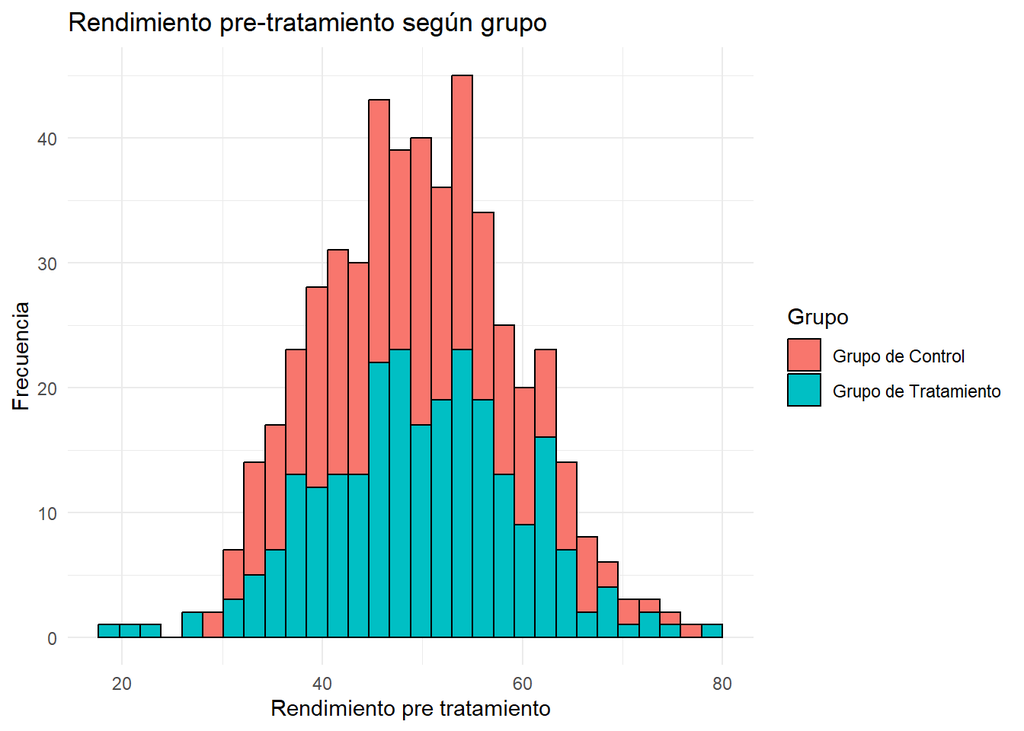

```r
# Realizar gráficos de rendimiento pre-tratamiento por grupo
ggplot(datos,aes(x=preT_rendimiento, fill=Grupo)) +
  geom_histogram(color="black") +
  theme_minimal() +
  labs(x = "Rendimiento pre tratamiento", y = "Frecuencia", title = "Rendimiento pre-tratamiento según grupo")
```

```r
# Realizar tabla con promedios de rendimiento pre-tratamiento por grupo
datos %>% dplyr::select(Grupo, preT_rendimiento) %>%
  group_by(Grupo) %>% summarize(Promedio = mean(preT_rendimiento, na.rm=TRUE))
```

```
## # A tibble: 2 × 2
##   Grupo                Promedio
##   <fct>                   <dbl>
## 1 Grupo de Control         49.0
## 2 Grupo de Tratamiento     49.8
```

24. Compare el rendimiento de los estudiantes después del tratamiento en el grupo de control (GC) y de tratamiento (GT) (Nota: dado que el GC no recibió el tratamiento, su rendimiento posterior al tratamiento es igual a su rendimiento inicial). Para hacer esta comparación copie y edite los comandos usados en el paso ix, para comparar la variable posT_rendimiento por grupo (en vez de preT_rendimiento). ¿Qué grupo tenía mayor rendimiento posterior al tratamiento? ¿Esperaba ese resultado? ¿Por qué?
11. Usando los datos de la tabla recién generada, estime el efecto del tratamiento (es decir, al rendimiento del GT posterior al tratamiento réstele el del GC)
12. Utilice el siguiente comando para estimar una RLS para predecir el rendimiento posterior al tratamiento, dependiendo de si el estudiante pertenece o no al GT. *lm* indica que se estimará un modelo lineal, en paréntesis, antes del signo ~ se indica la variable dependiente y después de este la variable independiente, después de data= se indica la base de datos a usar. *summary(model1)* mostrará el resumen del modelo estimado. ¿Qué indica el beta estimado? ¿Cómo se compara al efecto de tratamiento calculado en xi? ¿Cómo se compara al efecto de tratamiento definido en la simulación que generó los datos?

```r
model1 <- lm(posT_rendimiento ~ Grupo, data=datos)
summary(model1)
```

```
##
## Call:
## lm(formula = posT_rendimiento ~ Grupo, data = datos)
##
## Residuals:
##     Min      1Q  Median      3Q     Max
## -38.681  -7.317   0.102   7.092  27.919
##
## Coefficients:
##                           Estimate Std. Error t value Pr(>|t|)
## (Intercept)                48.9877     0.6671   73.44   <2e-16 ***
## GrupoGrupo de Tratamiento  16.1137     0.9434   17.08   <2e-16 ***
## ---
## Signif. codes:  0 '***' 0.001 '**' 0.01 '*' 0.05 '.' 0.1 ' ' 1
##
## Residual standard error: 10.55 on 498 degrees of freedom
## Multiple R-squared:  0.3694, Adjusted R-squared:  0.3682
## F-statistic: 291.8 on 1 and 498 DF,  p-value: < 2.2e-16
```

11. Guarde su script con el nombre tema5 parte 1.R

## **Parte 2: ¿Cuándo beta es un buen estimador?**

### **Parte 2: ¿Cuándo beta es un buen estimador?**

Nota: Este ejercicio está basado en el ejercicio “Activity 1: Randomized Trials” diseñado por el Prof. Spiro Maroulis (Disponible en: https://spiromar.github.io/teaching/paf573/IC1-randomized-trials.html).

1. En el simulador del experimento aleatorio, ejecute una simulación con los mismos parámetros pero con el parámetro *treatment-assignment=self-selection*, y descargue los datos.Renombre ese archivo student-data2.csv y guárdelo en su directorio. Defina su directorio, limpie el ambiente y cargue los paquetes readr, GGally, ggplot2, tidyverse. Importe los datos de student-data2.csv y llamelos datos2, renombre y modifique las variables tal como lo hizo con students-data1.csv.
2. Compare el NSE en el GT y el GC (modificando los comandos del paso ix., parte 1). ¿Qué diferencias existen?
3. Luego, estime la misma RLS de la parte 1, paso x. En la regresión estimada Y corresponde al rendimiento posterior al tratamiento e X corresponde al grupo, ¿Qué representaría el error entonces? ¿Qué indica el beta estimado? ¿Cómo se compara al efecto de tratamiento con el estimado usando students-data.csv? ¿Cómo se compara al efecto de tratamiento definido en la simulación que generó los datos?
4. Repita los pasos i-iii usando los siguientes parámetros en el simulador: *treatment-assignment=self-selection* y *treatment-ses-correlation=0*, guardando al archivo descargado como student-data3.csv e importandolo en el objeto datos 3.
5. Repita los pasos i-iii usando los siguientes parámetros en el simulador: *treatment-assignment=self-selection*, *treatment-ses-correlation=0,9* y *achievement-ses-correlation=0*, guardando al archivo descargado como student-data4.csv e importandolo en el objeto datos 4.
6. ¿Por qué la estimación del efecto causal en datos 4 se acerca al parámetro definido en la simulación si el GT tiene mayor NSE que el GC?
7. Guarde su script con el nombre tema5 parte 2.R

## **Parte 3: Explorando la distribución de beta**

### **Parte 3: Explorando la distribución de beta**

Nota: Este ejercicio se basa en “Activity 2:Understanding Sampling Distributions” diseñado por el Prof. Spiro Maroulis (Disponible en: https://spiromar.github.io/teaching/paf573/IC2-sampling-distributions.html).

En los análisis realizados hasta ahora nos enfocamos en observar la existencia de sesgo en la estimación de beta, pero poca atención pusimos en el hecho de que existe variación en los resultados. Si volvemos a ejecutar los mismos comandos para crear alguna de las bases de datos analizadas, encontraremos estimaciones similares, pero no idénticas. Uno de los motivos es que cada vez estamos analizando una realización del experimento, una muestra aleatoria, siendo que muchas otras muestras también eran posibles. Dado de que nuestras estimaciones varían de una muestra a otra, como econometristas, si encontramos un efecto beta estimado de cierta magnitud, nos gustaría saber en qué medida dicho beta es resultado de dicha variabilidad y en qué medida refleja el verdadero beta. El foco es: si en la realidad el tratamiento NO tiene efecto (beta=0), ¿Cuán probable es obtener un beta tan grande o más grande que el beta estimado con nuestra única muestra?

1. Haga clic [aquí](https://spiromar.github.io/teaching/paf573/sampling-dist.html) para entrar al simulador de experimento aleatorio. Este simulador es idéntico al anterior, pero incluye más monitores para poder observar más resultados. Modifique los parámetros del modelo para tengan los siguientes valores: *nbr-people = 150, treatment-effect = 0, treatment-assignment = “random”, achievement-ses-correlation = 0.7, treatment-ses-correlation = 0.6*.

[figure not shown]

2. Presiona Setup y luego Treat para correr una vez el experimento, ¿Cómo es el efecto del tratamiento estimado (estimated-effect)? Repite el ejercicio 4 veces más, ¿Cómo se comparan las estimaciones con el verdadero efecto del tratamiento?
3. En el simulador modifica al parámetro *N* asignale valor = 200. Luego presiona “repeat-N-times”, con lo cual ejecutarás 200 repeticiones del mismo experimento. Observa el gráfico “Frequency of effects across N Trials”. Este gráfico muestra el histograma de los efectos de tratamiento estimados en cada uno de los 200 experimentos. Comúnmente este gráfico es llamado “Distribución muestral de medias” ya que muestra como se distribuyen las medias obtenidas en cada muestra. En este caso, la media de una muestra corresponde al efecto de tratamiento promedio estimado en dicha muestra.
4. ¿Cuál es el promedio de la distribución muestral de medias? ¿y su desviación estándar? ¿Cuál es el mínimo y máximo de esta distribución? (Observe los monitores bajo el gráfico).
5. Suponga que ud. muestreo a 150 estudiantes y el 50% de ellos fue asignado aleatoriamente al tratamiento y el 50% no. Suponga que el efecto de tratamiento estimado corresponde a 2.5. Use la información de la distribución muestral de medias del simulador (gráfico y monitores), para aproximar cuán probable es que en la realidad el tratamiento tuviese un efecto nulo y que la diferencia que usted observa se deba meramente al azar.
6. En el simulador, cambie el parámetro *nbr-people* y asignale valor = 500. Ejecute 200 experimentos con esta especificación (Puede tomar algunos minutos).
7. ¿Cuál es el promedio de la distribución muestral de medias? ¿y su desviación estándar? ¿Cuál es el mínimo y máximo de esta distribución? (Observe los monitores bajo el gráfico).
8. Compare los valores obtenidos en xv. con los de x.ii, ¿Cómo se comparan?
9. ¿Qué preferiría usted usar una muestra de 150 casos o 500? ¿Por qué?
10. Suponga que ud. muestreo a 500 estudiantes y el 50% de ellos fue asignado aleatoriamente al tratamiento y el 50% no. Suponga que el efecto de tratamiento estimado corresponde a 2.5. Use la información de la distribución muestral de medias del simulador (gráfico y monitores), para aproximar cuán probable es que en la realidad el tratamiento tuviese un efecto nulo y que la diferencia que usted observa se deba meramente al azar.
11. En Estadística deben haber visto que cuando queríamos comparar medias, usabamos un test de hipótesis llamdo Test T. En ese test, el tipico estadistico es: (estimador - valor hipotético)/ error estándar del estimador. Probablemente estimaron este estadístico considerando que el estimador era el promedio de una muestra. En este caso, dado que el efecto de tratamiento estimado es un estimador, podemos estimar el estadístico T. Para ello, es importante recordar que el error estándar de un estimador, es la desviación estándar de este (es decir, el valor mostrado en el monitor “Std. Deviation of the effects”). Además, si consideramos la hipótesis nula (H0) de que el efecto de tratamiento es 0, usaríamos el valor 0 como valor hipotético. Esto nos permitiría estimar, cuán probable es observar el estadístico T observado o uno más extremo si fuese cierta. En el simulador, presiona *plot-tstats*. Esto convertirá los efectos de tratamiento estimado en cada uno de los 200 experimentos en un estadístico T, usando el valor 0 como valor hipotético y la fórmula indicada más arriba. El nuevo gráfico tendrá barras color verde, y básicamente representa la misma información; la única diferencia es que en vez de graficar el efecto casual estimado, graficamos una transformación de este (el estadístico T).
12. Suponga de nuevo, que ud. muestreo a 500 estudiantes y el 50% de ellos fue asignado aleatoriamente al tratamiento y el 50% no. Suponga que el efecto de tratamiento estimado corresponde a 2.5. Calcule cuál sería el estadístico T estimado, usando un valor hipotético de 0 y la desviación estándar de los efectos de tratamiento observados en el monitor tras las 200 simulaciones. Use la información de la distribución muestral de medias del simulador (gráfico y monitores), para aproximar cuán probable es que en la realidad el tratamiento tuviese un efecto nulo y que usted observe el T que estimó o uno más extremo. Esta estimación permitirá testear ¿Es el efecto de tratamiento distinto de 0 en la población? Sin embargo, en la realidad no solemos tener 200 muestras, sino 1. Entonces, ¿Cómo estimamos el error estándar del estimador? En clases abordaremos este tema.